# Exercise4

Alexandra Anderson

2023-10-02

## Don’t You Froget About Me

Why are frogs so bad at data analysis?

Because they jump to conclusions.

[figure not shown]

[video not shown]

This analysis was conducted using previously collected data on the California red-legged frog, which is California’s largest native frog. It is listed as federally threatened, in a large part due to habitat loss and introduction of the invasive American Bullfrog (who’s presence/absence was also recorded in this data set).

[Link to the data source](https://datadryad.org/stash/dataset/doi:10.5061/dryad.hc8qs61)

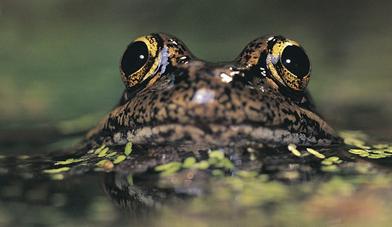

## Choosing My Data

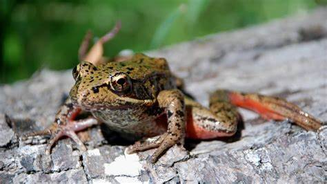

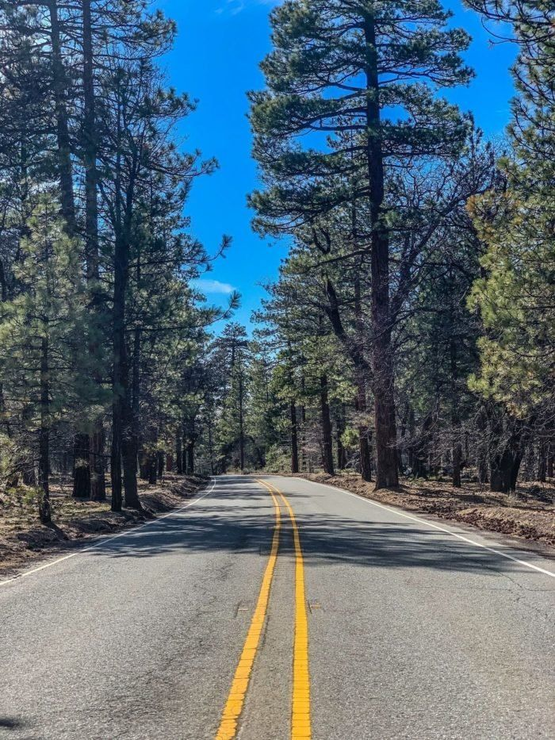

*A photo of a road in the San Bernadino NF, one of the places you can find these frogs*

I chose to use the distance from a paved road as the variable I weighed against California red-legged frog presence/absence. They also looked at a wide variety of other variables like distance from dirt roads and hiking trails as well as some vegetation, food and water variables.

```
## Rows: 67
## Columns: 48
## $ CRLF                  <dbl> 1, 1, 1, 1, 1, 1, 1, 1, 1, 1, 1, 1, 1, 1, 1, 1, …
## $ Bullfrog              <dbl> 0, 0, 0, 0, 0, 0, 0, 0, 0, 0, 0, 0, 0, 0, 0, 0, …
## $ BIGFROG               <dbl> 1, 1, 1, 1, 1, 1, 1, 1, 1, 1, 1, 1, 1, 1, 1, 1, …
## $ COEX                  <dbl> 0, 0, 0, 0, 0, 0, 0, 0, 0, 0, 0, 0, 0, 0, 0, 0, …
## $ Latitude              <dbl> 37, 36, 37, 37, 37, 37, 37, 37, 37, 37, 37, 37, …
## $ Longitude             <dbl> -122, -122, -121, -121, -121, -121, -121, -121, …
## $ Elevation             <dbl> 570.3, 464.5, 534.9, 659.0, 717.8, 563.0, 727.9,…
## $ Turbidity             <dbl> 4, 2, 4, 3, 2, 4, 2, 4, 5, 3, 2, 5, 2, 3, 4, 3, …
## $ WaterColor            <dbl> 2, 1, 1, 1, 1, 2, 1, 2, 3, 1, 1, 2, 1, 1, 2, 1, …
## $ MaxDepth              <dbl> 0.91, 1.22, 1.22, 3.05, 1.22, 1.22, 2.44, 1.22, …
## $ AvgDepth              <dbl> 0.46, 0.61, 0.61, 1.52, 0.91, 0.91, 1.83, 0.61, …
## $ CanopyCover           <dbl> 0, 0, 0, 0, 0, 0, 0, 0, 0, 0, 5, 0, 20, 0, 0, 0,…
## $ CANOPY1               <dbl> 0, 0, 0, 0, 0, 0, 0, 0, 0, 0, 2, 0, 2, 0, 0, 0, …
```

[output cut: 35 more lines]

## Binomial Plotting

Here is the plot for my chosen variables.

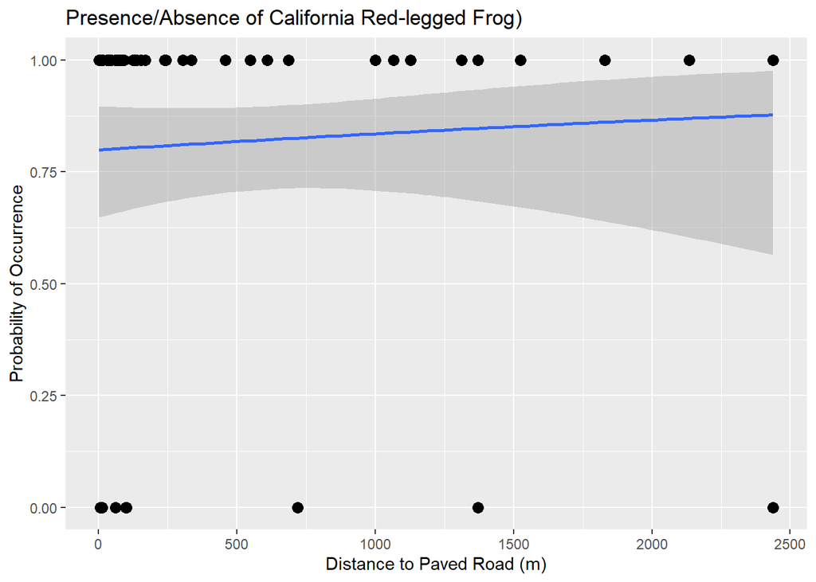

My initial model looking at my chosen variables.

```
##
## Call:  glm(formula = CRLF ~ PavedRoadDistance, family = binomial, data = frogs_filtered)
##
## Coefficients:
##       (Intercept)  PavedRoadDistance
##          1.380321           0.000242
##
## Degrees of Freedom: 66 Total (i.e. Null);  65 Residual
## Null Deviance:       63
## Residual Deviance: 63    AIC: 67
```

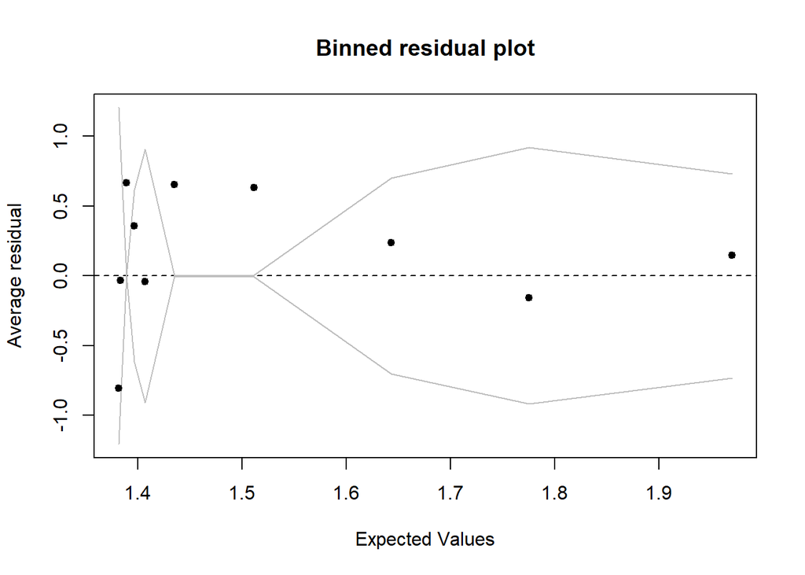

## Looking at the Model

```
##       (Intercept) PavedRoadDistance
##           1.38032           0.00024
```

```
##                      2.5 % 97.5 %
## (Intercept)        0.65242 2.2132
## PavedRoadDistance -0.00053 0.0012
```

```
##
## Call:
## glm(formula = CRLF ~ PavedRoadDistance, family = binomial, data = frogs_filtered)
##
## Coefficients:
##                   Estimate Std. Error z value Pr(>|z|)
## (Intercept)       1.380321   0.393667    3.51  0.00045 ***
## PavedRoadDistance 0.000242   0.000428    0.57  0.57154
## ---
## Signif. codes:  0 '***' 0.001 '**' 0.01 '*' 0.05 '.' 0.1 ' ' 1
##
## (Dispersion parameter for binomial family taken to be 1)
##
##     Null deviance: 62.984  on 66  degrees of freedom
## Residual deviance: 62.643  on 65  degrees of freedom
## AIC: 66.64
##
## Number of Fisher Scoring iterations: 4
```

In the model summary, the deviances are fairly similar, but there is no significant interaction between paved road distance and frog presence.

Fun Fact:

This is the frog that was referenced in Mark Twain’s short story “The Celebrates Jumping Frog of Calavera’s County”

[figure not shown]